# E2 Results

Alex Kale

2021-03-29

## Results

In this document, we present the results of our second experiment. This is intended as a supplement to the full paper. Here, we gather information from our exploratory analysis and model expansion processes, with an emphasis on what we’ve learned and an eye toward what should be presented in the paper.

### Analysis overview

Our primary research questions focus on how visualization conditions impact the correspondence between user responses and our normative benchmark *causal support*. Causal support says how much a chart user should believe in alternative causal explanations given a data set. In our second experiment, we ask users to differentiate between four alternative causal models accounting for the relationship between a gene, a treatment, and the disease that the treatment is known to prevent.

1. Explanation A: The gene has no effect on disease or treatment.
2. Explanation B: The gene causes an increase in disease but has no effect on treatment.
3. Explanation C: The gene has no effect on disease but stops the treatment from working.
4. Explanation D: The gene causes an increase in disease and stops the treatment from working (i.e., a confounding relationship).

We primarily investigate chart users’ ability to detect confounding (explanation D).

We estimate the correspondence between user responses and our normative benchmark using a linear in log odds (LLO) model, where ideal performance is a one-to-one relationship between a user’s responses and normative causal support. We characterize performance primarily in terms of LLO slopes with respect to causal support, which is a measure of sensitivity to the signal in each data set that should support causal inferences. The LLO also has an intercept term, which measures the average response when there is no signal to support any causal explanation. Intercepts represent an overall bias in responses to the extent that they deviate from the normative prior of 25% (assuming that the reasonable thing to do in the absence of signal would be to allocate equal probability to each of the four explanations).

We look at how LLO slopes and intercepts very as a function of visualization condition. In interactive visualization conditions, we separate trials depending on whether or not users interacted with the visualization, which reduces statistical power in these conditions but enables us to be more accurate in estimating the effects of interactive visualizations on causal inferences. At the end of the document we follow up and do a descriptive analysis of how chart users interacted with these visualizations, specifically, which views of the data they chose to create.

### Prepare data

Load data.

```r
df <- read_csv("e2-anonymous.csv")
head(df)
```

```
## # A tibble: 6 x 44
##   workerId batch bonus condition duration n_data_conds n_trials strategy
##   <chr>    <dbl> <dbl> <chr>        <dbl>        <dbl>    <dbl> <chr>
## 1 7819bfb6    69   2.5 text          752.           18       19 I looke…
## 2 7819bfb6    69   2.5 text          752.           18       19 I looke…
## 3 7819bfb6    69   2.5 text          752.           18       19 I looke…
## 4 7819bfb6    69   2.5 text          752.           18       19 I looke…
## 5 7819bfb6    69   2.5 text          752.           18       19 I looke…
## 6 7819bfb6    69   2.5 text          752.           18       19 I looke…
## # … with 36 more variables: confidence <dbl>, gender <chr>, age <chr>,
## #   education <chr>, chart_use <chr>, abs_err <dbl>, causal_support <dbl>,
## #   causal_support_d <dbl>, causal_support_t <dbl>, count_GT <dbl>,
## #   count_GnT <dbl>, count_nGT <dbl>, count_nGnT <dbl>, ground_truth <dbl>,
## #   interactions <chr>, llA <dbl>, llB <dbl>, llC <dbl>, llD <dbl>, n <dbl>,
## #   p_gene_d <dbl>, p_gene_t <dbl>, payoff <dbl>, q_idx <dbl>,
## #   response_A <dbl>, response_B <dbl>, response_C <dbl>, response_D <dbl>,
## #   total_GT <dbl>, total_GnT <dbl>, total_nGT <dbl>, total_nGnT <dbl>,
## #   trial <chr>, trial_dur <dbl>, trial_idx <dbl>, userInput <chr>
```

Transform user responses into log response ratios `lrr` so we can model responses as a function of `causal_support` in log odds units. Also, convert predictor variables to factors for modeling if need be.

```r
model_df <- df %>%
  # drop practice trial
  filter(trial != "practice") %>%
  mutate(
    # response units
    response_A =  if_else(
      response_A > 99.5, 99.5,
      if_else(
        response_A < 0.5, 0.5,
        as.numeric(response_A))),
    response_B =  if_else(
      response_B > 99.5, 99.5,
      if_else(
        response_B < 0.5, 0.5,
        as.numeric(response_B))),
    response_C = if_else(
      response_C > 99.5, 99.5,
      if_else(
        response_C < 0.5, 0.5,
        as.numeric(response_C))),
    response_D = if_else(
      response_D > 99.5, 99.5,
      if_else(
        response_D < 0.5, 0.5,
        as.numeric(response_D))),
    # calculate log response ratios
    lrr = log(response_D / 100) - log(response_A / 100 + response_B / 100 + response_C / 100),
    lrr_d = log(response_B / 100 + response_D / 100) - log(response_A / 100 + response_C / 100),
    lrr_t = log(response_C / 100 + response_D / 100) - log(response_A / 100 + response_B / 100),
    # predictors as factors
    worker = as.factor(workerId),
    condition = as.factor(condition),
    n = as.factor(n),
    # derived predictors
    delta_p_d = (count_nGnT + count_nGT) / (total_nGnT + total_nGT) - (count_GnT + count_GT) / (total_GnT + total_GT),
    delta_p_t = count_nGT / total_nGT - count_GT / total_GT,
    interactions_processed = if_else(interactions == "placeholder", list(NA), str_split(interactions, "_")),
    trial = as.numeric(trial),
    trial_n = (trial - mean(trial)) / max(trial) # normalized trial indices
  ) %>%
  rowwise() %>%
  # boolean to code for any interaction whatsoever
  mutate(interact = !any(is.na(unlist(interactions_processed)))) %>%
  # subset trial in the interactive condition depending on whether users interact at all, treating these as different factors
  unite("vis", condition, interact, remove = FALSE) %>%
  mutate(
    # order vis conditions
    vis_order = case_when(
      as.character(vis) == "text_FALSE"     ~ 1,
      as.character(vis) == "icons_FALSE"    ~ 2,
      as.character(vis) == "bars_FALSE"     ~ 3,
      as.character(vis) == "aggbars_FALSE"  ~ 4,
      as.character(vis) == "aggbars_TRUE"   ~ 5,
      as.character(vis) == "filtbars_FALSE" ~ 6,
      as.character(vis) == "filtbars_TRUE"  ~ 7,
      TRUE                                  ~ 0
    )
  )
```

Let’s exclude workers who miss the trial where causal support is the largest. In our preregistration, we defined a miss as responding less than 25% (i.e., less than the normative prior) when the normative response is about 100% (i.e., when signal is maxed out). However, this criterion seems to strict since it excludes 39% of our sample. We decided to relax the criterion to exclude only users who answered less than 20%, essentially allowing for 5% response error and dropping our exclusion rate to 26% similar to E1.

```r
exclude_df <- model_df %>%
  group_by(workerId) %>%
  summarise(
    max_trial_idx = which(trial_idx == -1)[1],
    max_trial_response_D = response_D[[max_trial_idx]],
    exclude = max_trial_response_D < 20
  )
head(exclude_df)
```

```
## # A tibble: 6 x 4
##   workerId max_trial_idx max_trial_response_D exclude
##   <chr>            <int>                <dbl> <lgl>
## 1 005a1c7a            10                 30   FALSE
## 2 0097df14            10                 99.5 FALSE
## 3 00d941e1            10                 23.3 FALSE
## 4 02f5c174            10                 20   FALSE
## 5 04579941            10                 17.2 TRUE
## 6 04f4574f            10                 15   TRUE
```

Apply the exclusion criteria.

```r
model_df = exclude_df %>%
  select(workerId, exclude) %>%
  full_join(model_df, by = "workerId") %>%
  filter(!exclude) %>%
  select(-exclude)
```

Additionally, we’ll drop all attention check trials now that we are done using them for exclusions.

```r
model_df = model_df %>%
  filter(trial_idx != -1)
```

How many participants per condition after exclusions? (target sample size was 100 per condition)

```r
model_df %>%
  group_by(condition) %>%
  summarise(
    n = length(unique(workerId))
  )
```

```
## # A tibble: 5 x 2
##   condition     n
##   <fct>     <int>
## 1 aggbars     104
## 2 bars        102
## 3 filtbars    111
## 4 icons       101
## 5 text        101
```

We overshot our target sample size slightly in all conditions. This happened because we launch HITs in batches on MTurk, and it is hard to anticipate how many people in a batch will pass the exclusion criterion. The few extra participants should not make much of a difference in our results.

### Inferential models

This is the primary model that we will use statistical inferences, and it is the result of our preregistered model expansion process. See ModelExpansion.Rmd for more information about how we arrived at this model.

```r
m <- brm(data = model_df, family = "gaussian",
  formula = bf(lrr ~ causal_support*delta_p_d*delta_p_t*n*vis + (causal_support*delta_p_d + causal_support*delta_p_t + causal_support*n|workerId)),
  prior = c(prior(normal(-1.703593, 1), class = Intercept),          # center at mean(qlogis(model_df$response_D / 100))
            prior(normal(0, 0.5), class = b),                        # center predictor effects at 0
            prior(normal(1, 0.5), class = b, coef = causal_support), # center at unbiased slope
            prior(normal(0, 0.5), class = sigma),                    # weakly informative half-normal
            prior(normal(0, 0.5), class = sd),                       # weakly informative half-normal
            prior(lkj(4), class = cor)),                             # avoiding large correlations
  iter = 4000, warmup = 500, chains = 2, cores = 2,
  control = list(adapt_delta = 0.99, max_treedepth = 12),
  file = "model-fits/6a_re-within")
```

```r
summary(m)
```

```
##  Family: gaussian
##   Links: mu = identity; sigma = identity
## Formula: lrr ~ causal_support * delta_p_d * delta_p_t * n * vis + (causal_support * delta_p_d + causal_support * delta_p_t + causal_support * n | workerId)
##    Data: model_df (Number of observations: 9342)
## Samples: 2 chains, each with iter = 4000; warmup = 500; thin = 1;
##          total post-warmup samples = 7000
##
## Group-Level Effects:
## ~workerId (Number of levels: 519)
##                                                        Estimate Est.Error
## sd(Intercept)                                              1.17      0.07
## sd(causal_support)                                         0.12      0.02
## sd(delta_p_d)                                              1.70      0.21
## sd(delta_p_t)                                              2.52      0.21
## sd(n1000)                                                  0.20      0.08
## sd(causal_support:delta_p_d)                               0.07      0.05
## sd(causal_support:delta_p_t)                               0.15      0.05
## sd(causal_support:n1000)                                   0.04      0.02
## cor(Intercept,causal_support)                             -0.29      0.12
## cor(Intercept,delta_p_d)                                   0.41      0.09
## cor(causal_support,delta_p_d)                             -0.32      0.15
## cor(Intercept,delta_p_t)                                   0.70      0.06
## cor(causal_support,delta_p_t)                             -0.38      0.13
## cor(delta_p_d,delta_p_t)                                   0.05      0.14
## cor(Intercept,n1000)                                       0.08      0.19
## cor(causal_support,n1000)                                 -0.04      0.23
## cor(delta_p_d,n1000)                                      -0.12      0.21
## cor(delta_p_t,n1000)                                       0.33      0.20
## cor(Intercept,causal_support:delta_p_d)                   -0.05      0.23
## cor(causal_support,causal_support:delta_p_d)               0.28      0.27
## cor(delta_p_d,causal_support:delta_p_d)                   -0.13      0.25
## cor(delta_p_t,causal_support:delta_p_d)                   -0.08      0.24
## cor(n1000,causal_support:delta_p_d)                        0.08      0.25
## cor(Intercept,causal_support:delta_p_t)                    0.04      0.17
## cor(causal_support,causal_support:delta_p_t)               0.43      0.20
## cor(delta_p_d,causal_support:delta_p_t)                   -0.35      0.20
## cor(delta_p_t,causal_support:delta_p_t)                   -0.10      0.18
## cor(n1000,causal_support:delta_p_t)                        0.02      0.23
## cor(causal_support:delta_p_d,causal_support:delta_p_t)    -0.05      0.27
## cor(Intercept,causal_support:n1000)                        0.27      0.23
```

[output cut: 527 more lines]

```
## delta_p_d:delta_p_t:n1000:vistext_FALSE                        5437
## causal_support:delta_p_d:delta_p_t:n1000:visaggbars_TRUE       5080
## causal_support:delta_p_d:delta_p_t:n1000:visbars_FALSE         5113
## causal_support:delta_p_d:delta_p_t:n1000:visfiltbars_FALSE     4481
## causal_support:delta_p_d:delta_p_t:n1000:visfiltbars_TRUE      5039
## causal_support:delta_p_d:delta_p_t:n1000:visicons_FALSE        5114
## causal_support:delta_p_d:delta_p_t:n1000:vistext_FALSE         5433
##
## Family Specific Parameters:
##       Estimate Est.Error l-95% CI u-95% CI Rhat Bulk_ESS Tail_ESS
## sigma     1.31      0.01     1.29     1.33 1.00     2635     4499
##
## Samples were drawn using sampling(NUTS). For each parameter, Eff.Sample
## is a crude measure of effective sample size, and Rhat is the potential
## scale reduction factor on split chains (at convergence, Rhat = 1).
```

We will also load two secondary models that we use to break down chart users’ ability to detect the component signals of confounding, the effect of gene on disease (explanations B or D) and the effect of gene on treatment (explanations C or D).

```r
m_delta_p_d <- brm(data = model_df, family = "gaussian",
  formula = bf(lrr_d ~ causal_support_d*delta_p_d*n*vis + (causal_support_d|workerId)),
  prior = c(prior(normal(0.05933661, 1), class = Intercept),           # center at mean(qlogis(model_df$response_B / 100 + model_df$response_D / 100))
            prior(normal(0, 0.5), class = b),                          # center predictor effects at 0
            prior(normal(1, 0.5), class = b, coef = causal_support_d), # center at unbiased slope
            prior(normal(0, 0.5), class = sigma),                      # weakly informative half-normal
            prior(normal(0, 0.5), class = sd),                         # weakly informative half-normal
            prior(lkj(4), class = cor)),                               # avoiding large correlations
  iter = 4000, warmup = 500, chains = 2, cores = 2,
  control = list(adapt_delta = 0.99, max_treedepth = 12),
  file = "model-fits/delta_p_d-re-simple")
```

```r
summary(m_delta_p_d)
```

```
##  Family: gaussian
##   Links: mu = identity; sigma = identity
## Formula: lrr_d ~ causal_support_d * delta_p_d * n * vis + (causal_support_d | workerId)
##    Data: model_df (Number of observations: 9342)
## Samples: 2 chains, each with iter = 4000; warmup = 500; thin = 1;
##          total post-warmup samples = 7000
##
## Group-Level Effects:
## ~workerId (Number of levels: 519)
##                                 Estimate Est.Error l-95% CI u-95% CI Rhat
## sd(Intercept)                       0.70      0.03     0.64     0.76 1.00
## sd(causal_support_d)                0.02      0.00     0.02     0.02 1.00
## cor(Intercept,causal_support_d)    -0.39      0.05    -0.49    -0.29 1.00
##                                 Bulk_ESS Tail_ESS
## sd(Intercept)                       2331     4067
## sd(causal_support_d)                2186     3899
## cor(Intercept,causal_support_d)     1679     2996
##
## Population-Level Effects:
##                                                    Estimate Est.Error l-95% CI
## Intercept                                             -0.83      0.09    -1.01
## causal_support_d                                       0.37      0.03     0.31
## delta_p_d                                             -2.27      0.30    -2.85
## n1000                                                 -0.62      0.10    -0.81
## visaggbars_TRUE                                        0.18      0.19    -0.19
## visbars_FALSE                                         -0.06      0.14    -0.31
## visfiltbars_FALSE                                      0.74      0.17     0.42
## visfiltbars_TRUE                                       0.27      0.14     0.00
## visicons_FALSE                                        -0.16      0.13    -0.43
## vistext_FALSE                                          0.03      0.13    -0.23
## causal_support_d:delta_p_d                             0.53      0.06     0.42
## causal_support_d:n1000                                -0.32      0.03    -0.39
## delta_p_d:n1000                                       -1.56      0.35    -2.24
## causal_support_d:visaggbars_TRUE                      -0.10      0.08    -0.24
## causal_support_d:visbars_FALSE                        -0.07      0.04    -0.15
## causal_support_d:visfiltbars_FALSE                    -0.43      0.06    -0.54
## causal_support_d:visfiltbars_TRUE                     -0.17      0.05    -0.27
## causal_support_d:visicons_FALSE                       -0.05      0.04    -0.13
## causal_support_d:vistext_FALSE                        -0.15      0.05    -0.24
## delta_p_d:visaggbars_TRUE                             -0.19      0.48    -1.13
```

[output cut: 143 more lines]

```
## delta_p_d:n1000:vistext_FALSE                          5668
## causal_support_d:delta_p_d:n1000:visaggbars_TRUE       2840
## causal_support_d:delta_p_d:n1000:visbars_FALSE         1913
## causal_support_d:delta_p_d:n1000:visfiltbars_FALSE     3114
## causal_support_d:delta_p_d:n1000:visfiltbars_TRUE      2209
## causal_support_d:delta_p_d:n1000:visicons_FALSE        2204
## causal_support_d:delta_p_d:n1000:vistext_FALSE         2002
##
## Family Specific Parameters:
##       Estimate Est.Error l-95% CI u-95% CI Rhat Bulk_ESS Tail_ESS
## sigma     1.64      0.01     1.62     1.67 1.00    10505     5719
##
## Samples were drawn using sampling(NUTS). For each parameter, Eff.Sample
## is a crude measure of effective sample size, and Rhat is the potential
## scale reduction factor on split chains (at convergence, Rhat = 1).
```

```r
m_delta_p_t <- brm(data = model_df, family = "gaussian",
  formula = bf(lrr_t ~ causal_support_t*delta_p_t*n*vis + (causal_support_t|workerId)),
  prior = c(prior(normal(-0.3172157, 1), class = Intercept),           # center at mean(qlogis(model_df$response_C / 100 + model_df$response_D / 100))
            prior(normal(0, 0.5), class = b),                          # center predictor effects at 0
            prior(normal(1, 0.5), class = b, coef = causal_support_t), # center at unbiased slope
            prior(normal(0, 0.5), class = sigma),                      # weakly informative half-normal
            prior(normal(0, 0.5), class = sd),                         # weakly informative half-normal
            prior(lkj(4), class = cor)),                               # avoiding large correlations
  iter = 4000, warmup = 500, chains = 2, cores = 2,
  control = list(adapt_delta = 0.99, max_treedepth = 12),
  file = "model-fits/delta_p_t-re-simple")
```

```r
summary(m_delta_p_t)
```

```
##  Family: gaussian
##   Links: mu = identity; sigma = identity
## Formula: lrr_t ~ causal_support_t * delta_p_t * n * vis + (causal_support_t | workerId)
##    Data: model_df (Number of observations: 9342)
## Samples: 2 chains, each with iter = 4000; warmup = 500; thin = 1;
##          total post-warmup samples = 7000
##
## Group-Level Effects:
## ~workerId (Number of levels: 519)
##                                 Estimate Est.Error l-95% CI u-95% CI Rhat
## sd(Intercept)                       0.81      0.03     0.75     0.87 1.00
## sd(causal_support_t)                0.14      0.01     0.13     0.15 1.00
## cor(Intercept,causal_support_t)    -0.64      0.04    -0.72    -0.57 1.00
##                                 Bulk_ESS Tail_ESS
## sd(Intercept)                       2543     4290
## sd(causal_support_t)                2630     4350
## cor(Intercept,causal_support_t)     2710     4201
##
## Population-Level Effects:
##                                                    Estimate Est.Error l-95% CI
## Intercept                                             -1.06      0.10    -1.25
## causal_support_t                                       0.44      0.06     0.33
## delta_p_t                                             -3.00      0.22    -3.43
## n1000                                                 -0.32      0.09    -0.49
## visaggbars_TRUE                                       -0.25      0.18    -0.60
## visbars_FALSE                                          0.09      0.14    -0.18
## visfiltbars_FALSE                                      0.72      0.17     0.39
## visfiltbars_TRUE                                       0.14      0.14    -0.14
## visicons_FALSE                                         0.05      0.14    -0.23
## vistext_FALSE                                          0.31      0.14     0.04
## causal_support_t:delta_p_t                             0.57      0.14     0.31
## causal_support_t:n1000                                -0.34      0.06    -0.45
## delta_p_t:n1000                                       -0.74      0.29    -1.31
## causal_support_t:visaggbars_TRUE                      -0.11      0.14    -0.39
## causal_support_t:visbars_FALSE                         0.13      0.08    -0.03
## causal_support_t:visfiltbars_FALSE                    -0.49      0.11    -0.71
## causal_support_t:visfiltbars_TRUE                     -0.22      0.09    -0.40
## causal_support_t:visicons_FALSE                        0.03      0.08    -0.13
## causal_support_t:vistext_FALSE                        -0.08      0.09    -0.25
## delta_p_t:visaggbars_TRUE                             -0.01      0.42    -0.85
```

[output cut: 143 more lines]

```
## delta_p_t:n1000:vistext_FALSE                          5694
## causal_support_t:delta_p_t:n1000:visaggbars_TRUE       5072
## causal_support_t:delta_p_t:n1000:visbars_FALSE         4391
## causal_support_t:delta_p_t:n1000:visfiltbars_FALSE     4851
## causal_support_t:delta_p_t:n1000:visfiltbars_TRUE      4364
## causal_support_t:delta_p_t:n1000:visicons_FALSE        4193
## causal_support_t:delta_p_t:n1000:vistext_FALSE         4427
##
## Family Specific Parameters:
##       Estimate Est.Error l-95% CI u-95% CI Rhat Bulk_ESS Tail_ESS
## sigma     1.57      0.01     1.54     1.59 1.00    11009     5671
##
## Samples were drawn using sampling(NUTS). For each parameter, Eff.Sample
## is a crude measure of effective sample size, and Rhat is the potential
## scale reduction factor on split chains (at convergence, Rhat = 1).
```

### Main effects of visualization

*Recall:* We estimate the correspondence between user responses and our normative benchmark using a linear in log odds (LLO) model, where ideal performance is a one-to-one relationship between a user’s responses and normative causal support. We chartacterize performance primarily in terms of LLO slopes with respect to causal support, which is a measure of sensitivity to the signal in each data set that should support causal inferences. The LLO also has an intercept term, which measures the average response when there is no signal to support either causal explanation. Intercepts represent an overall bias in responses to the extent that they deviate from 25%.

To start, lets derive slopes and intercepts from our primary model.

```r
# extract conditional expectations from model
results_df <- model_df %>%
  group_by(n, vis, vis_order) %>%
  data_grid(
    causal_support = c(qlogis(0.25), qlogis(0.25) + 1),
    delta_p_d = quantile(model_df$delta_p_d, probs = plogis(seq(from = qlogis(0.001), to = qlogis(0.999), length.out = 20))),
    delta_p_t = quantile(model_df$delta_p_t, probs = plogis(seq(from = qlogis(0.001), to = qlogis(0.999), length.out = 20)))) %>%
  add_fitted_draws(m, value = "lrr_rep", seed = 1234, n = 500, re_formula = NA) %>%
  select(-one_of(c(".row",".chain",".iteration")))
# derive slopes
slopes_df <- results_df %>%
  compare_levels(lrr_rep, by = causal_support) %>%
  rename(slope = lrr_rep)

# derive intercepts and merge dataframes
results_df <- results_df %>%
  filter(abs(causal_support - qlogis(0.25)) < .Machine$double.eps) %>%
  rename(intercept = lrr_rep) %>%
  full_join(slopes_df, by = c("n", "vis", "vis_order", "delta_p_d", "delta_p_t", ".draw"))
```

Let’s also drive slopes for our two secondary models, which separately capture causal support for each component of the confounding relationship represented in the primary model.

```r
slopes_delta_p_d_df <- model_df %>%
  group_by(n, vis, vis_order) %>%
  data_grid(
    causal_support_d = c(0, 1),
    delta_p_d = quantile(model_df$delta_p_d, probs = plogis(seq(from = qlogis(0.001), to = qlogis(0.999), length.out = 20)))) %>%
  add_fitted_draws(m_delta_p_d, value = "lrr_d_rep", seed = 1234, n = 500, re_formula = NA) %>%
  compare_levels(lrr_d_rep, by = causal_support_d) %>%
  rename(slope = lrr_d_rep)
```

```r
slopes_delta_p_t_df <- model_df %>%
  group_by(n, vis, vis_order) %>%
  data_grid(
    causal_support_t = c(0, 1),
    delta_p_t = quantile(model_df$delta_p_t, probs = plogis(seq(from = qlogis(0.001), to = qlogis(0.999), length.out = 20)))) %>%
  add_fitted_draws(m_delta_p_t, value = "lrr_t_rep", seed = 1234, n = 500, re_formula = NA) %>%
  compare_levels(lrr_t_rep, by = causal_support_t) %>%
  rename(slope = lrr_t_rep)
```

Let’s look at posterior estimates of the slope and intercept in each visualization condition.

We’ll start with *slopes*.

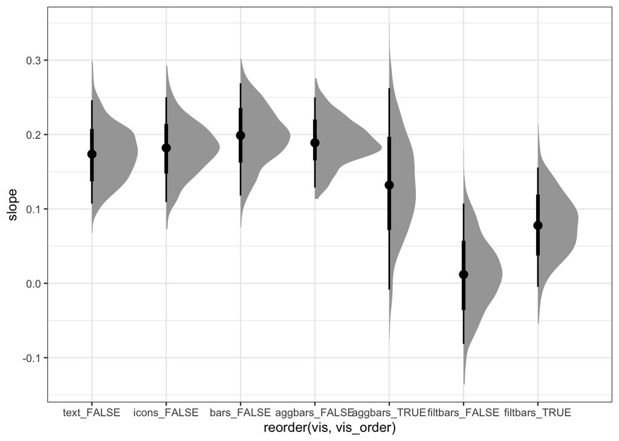

```r
results_df %>%
  group_by(vis, vis_order, .draw) %>%          # group by predictors to keep
  summarise(slope = weighted.mean(slope)) %>%  # marginalize
  ggplot(aes(x = reorder(vis, vis_order), y = slope)) +
    stat_halfeye() +
    theme_bw()
```

```r
# figure for paper
plt <- results_df %>%
  group_by(vis, vis_order, .draw) %>%          # group by predictors to keep
  summarise(slope = weighted.mean(slope)) %>%  # marginalize
  ggplot(aes(x = slope, y = reorder(vis, desc(vis_order)))) +
    stat_slabh() +
    theme_minimal() +
    theme(
      axis.title = element_blank(),
      panel.grid.minor = element_blank()
    )

plt
# ggsave("../../figures/components/e2-slopes.svg", plt, width = 3, height = 2)
```

Let’s look at pairwise contrasts to see reliability of these visualization effects on LLO slopes. We’ll flip the coordinates so we have more space to put the labels for each pairwise difference.

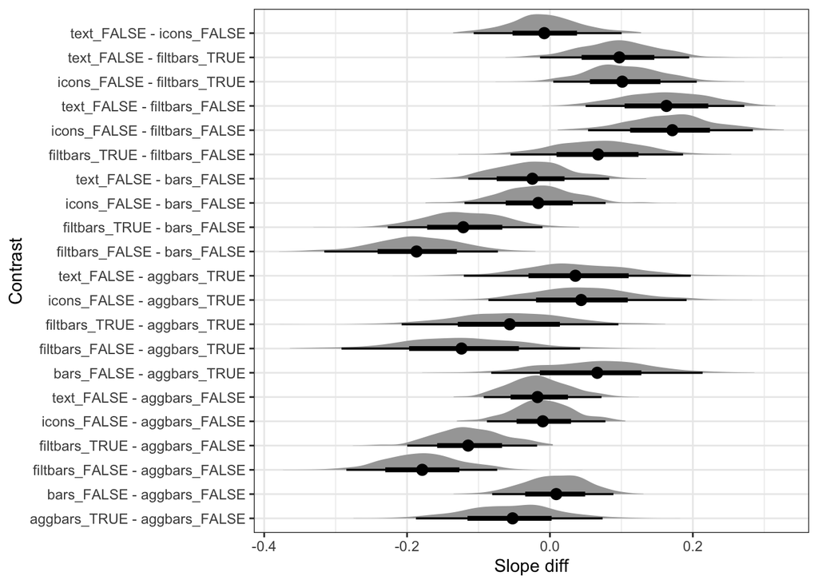

```r
slopes_df %>%
  group_by(vis, .draw) %>%                    # group by predictors to keep
  summarise(slope = weighted.mean(slope)) %>% # marginalize
  compare_levels(slope, by = vis) %>%
  ggplot(aes(x = slope, y = vis)) +
    stat_halfeyeh() +
    theme_bw() +
    labs(
      x = "Slope diff",
      y = "Contrast"
    )
```

When users do not interact with filtbars, they do terrible, but their performance seems to improve (though not reliably) when they take the time to interact. We expected to see this improvement in performance insofar as the task should be impossible if users do not interact with filtbars since the signal in the chart is hidden behind interactions.

Interestingly, users seem to perform slightly (though not reliably) worse with aggbars when they take the time to interact with the visualization which is unexpected. In the paper, we remark on why we might see opposite directions of effects of interacting with aggbars vs filtbars.

Now, let’s look at *intercepts*.

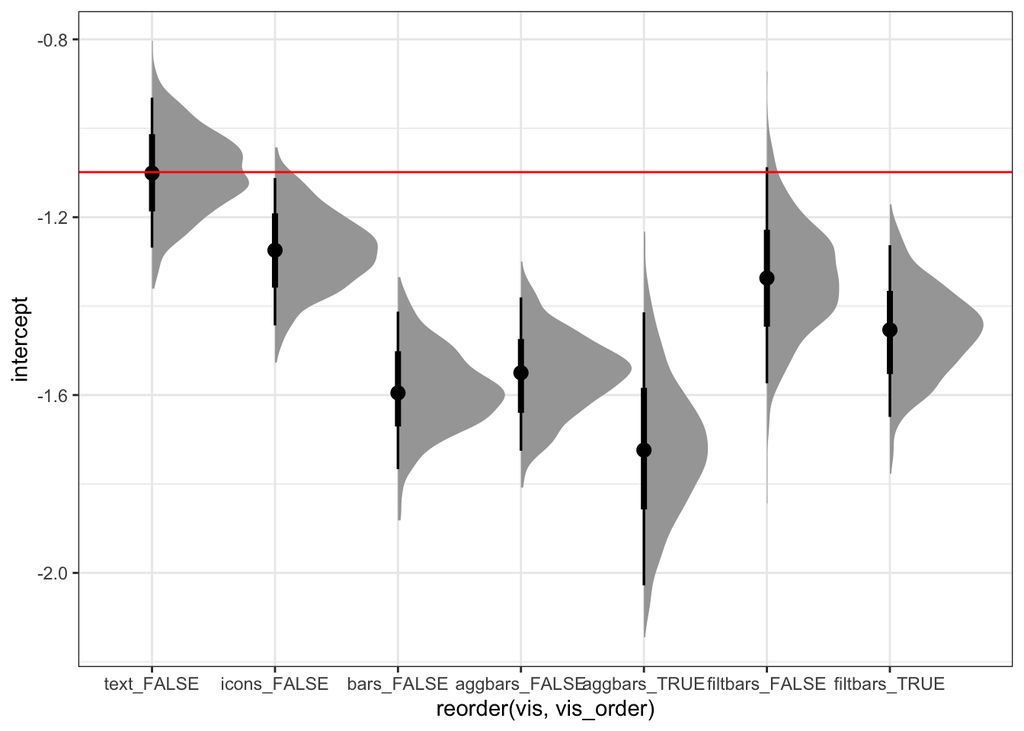

```r
results_df %>%
  group_by(vis, vis_order, .draw) %>%                 # group by predictors to keep
  summarise(intercept = weighted.mean(intercept)) %>% # marginalize
  ggplot(aes(x = reorder(vis, vis_order), y = intercept)) +
    stat_halfeye() +
    geom_hline(yintercept = qlogis(0.25), color = "red") +
    theme_bw()
```

As before, let’s look at pairwise contrasts to see reliability of these visualization effects on LLO intercepts.

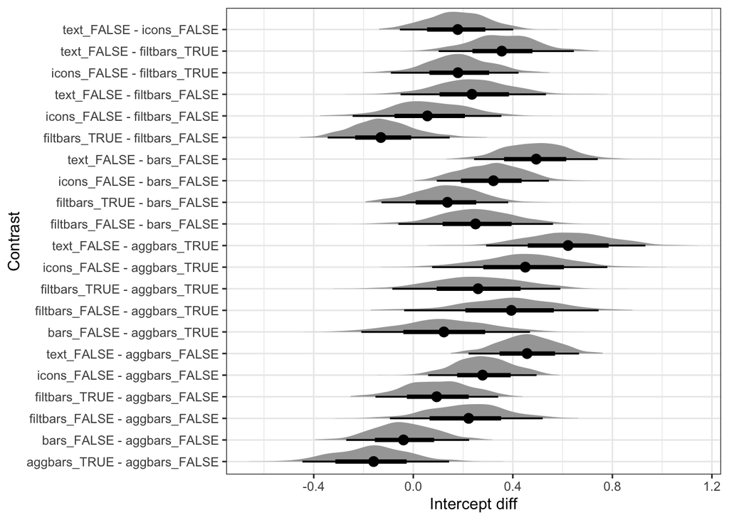

```r
results_df %>%
  group_by(vis, .draw) %>%                            # group by predictors to keep
  summarise(intercept = weighted.mean(intercept)) %>% # marginalize
  compare_levels(intercept, by = vis) %>%
  ggplot(aes(x = intercept, y = vis)) +
    stat_halfeyeh() +
    theme_bw() +
    labs(
      x = "Intercept diff",
      y = "Contrast"
    )
```

These intercepts show substantial response bias when there is no signal to support either causal explanation for all conditions but text, with more bias in the bars and aggbars conditions. The biases we see suggest that chart users in most conditions underestimate the probability of a confounding relationship.

Text and filtbars when users don’t interact are unique in that users average response in the absence of signal is not reliably different from the normative response.

Effects of interaction are not reliable, but underestimation bias seems to increase slightly when users interact with aggbars and filtbars.

*We can also frame these slopes and intercepts in terms of the response scale.*

On the response scale, *slopes* are a change in the average user’s subjective probability that there is a treatment effect given an increase in ground truth from `plogis(qlogis(0.25)) = 0.25` to `plogis(qlogis(0.25) + 1) = 0.48`. A slope of 1 corresponds to an increase of 23% in the normative probability of a treatment effect.

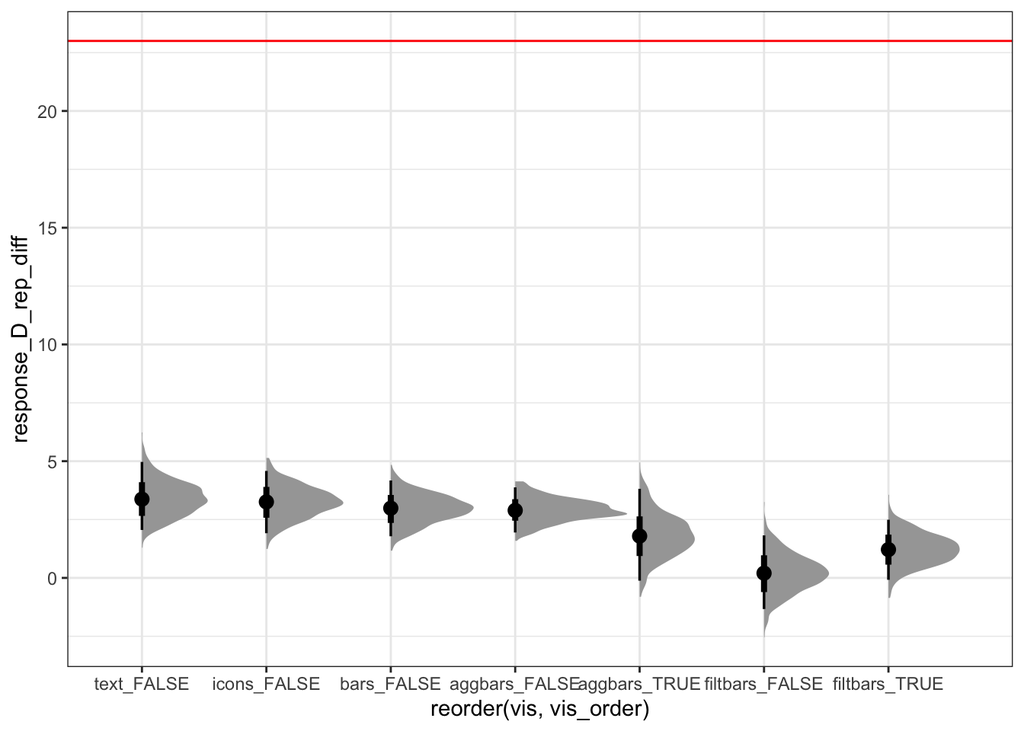

```r
results_df %>%
  group_by(vis, vis_order, .draw) %>% # group by predictors to keep
  summarise(                          # marginalize
    slope = weighted.mean(slope),
    intercept = weighted.mean(intercept)
  ) %>%
  mutate(
    response_D_rep_diff = (plogis(slope + intercept) - plogis(intercept)) * 100
  ) %>%
  ggplot(aes(x = reorder(vis, vis_order), y = response_D_rep_diff)) +
    stat_halfeye() +
    geom_hline(yintercept = 23, color = "red") +
    theme_bw()
```

This view of the data reiterates that people are far less sensitive to the signal in the charts than they should be.

On the response scale, *intercepts* are just the average response where the ground truth is `plogis(qlogis(0.25)) = 0.25`. A response of 25% is ideal when there is no signal in the data.

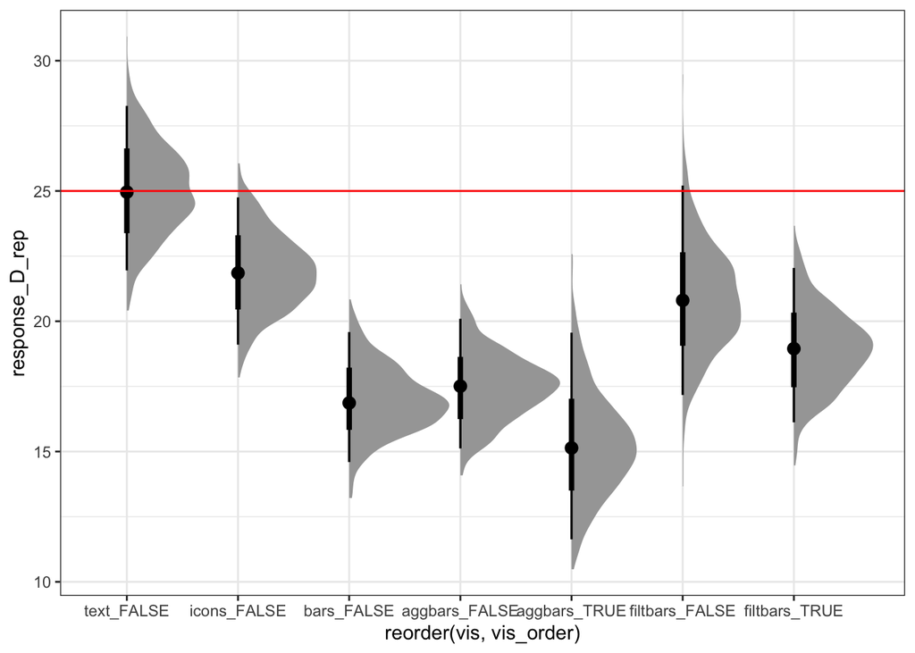

```r
results_df %>%
  group_by(vis, vis_order, .draw) %>% # group by predictors to keep
  summarise(                          # marginalize
    intercept = weighted.mean(intercept)
  ) %>%
  mutate(
    response_D_rep = plogis(intercept) * 100
  ) %>%
  ggplot(aes(x = reorder(vis, vis_order), y = response_D_rep)) +
    stat_halfeye() +
    geom_hline(yintercept = 25, color = "red") +
    theme_bw()
```

```r
# figure for paper
plt <- results_df %>%
  group_by(vis, vis_order, .draw) %>% # group by predictors to keep
  summarise(                          # marginalize
    intercept = weighted.mean(intercept)
  ) %>%
  mutate(
    response_D_rep = plogis(intercept) * 100
  ) %>%
  ggplot(aes(x = response_D_rep, y = reorder(vis, desc(vis_order)))) +
    stat_slabh() +
    geom_vline(xintercept = 25, color = "red") +
    theme_minimal() +
    theme(
      axis.title = element_blank(),
      panel.grid.minor = element_blank()
    )

plt
# ggsave("../../figures/components/e2-intercepts.svg", plt, width = 3, height = 2)
```

This view of the data helps us make sense of the magnitude of bias in the task. For example, users are underestimating the probability of a treatment effect by as much as 10% with bar charts. This is a practically important amount of bias, and it’s worth noting that the pattern of bias across visualization conditions is not the same as in E1.

### Interactions of visualization with delta p and sample size

In addition to how LLO slopes vary as a function of visualization condition, we want to investigate what aspects of the signal in a chart users seems to struggle to interpret. *The signal in our task for experiment 2 can be broken down into three attributes of the stimulus: delta p disease, delta p treatment, and sample size.*

*Delta p disease* is the difference in the proportion of people in each data set with the disease depending on whether they did vs didn’t have the gene. Negative values of delta p disease indicate that a greater proportion of people had the disease in the gene group than in the no gene group (i.e., evidence for the gene effect on disease). Positive values of delta p disease indicate that a smaller proportion of people had the disease in the gene group than in the no gene group (i.e., evidence against the gene effect on disease).

*Delta p treatment* is the difference in the proportion of people *who received treatment* in each data set with the disease depending on whether they did vs didn’t have the gene. Negative values of delta p treatment indicate that a greater proportion of people who received treatment had the disease in the gene group than in the no gene group (i.e., evidence for the gene effect on treatment). Positive values of delta p treatment indicate that a smaller proportion of people who received treatment had the disease in the gene group than in the no gene group (i.e., evidence against the gene effect on treatment).

*Sample size* is just the overall number of people in the fake data sets we showed on each trial.

In the ideal observer, there should be no residual effects of delta p disease, delta p treatment, and sample size after we’ve adjusted for the influence of causal support on user judgments. However, users have perceptual and cognitive biases in interpreting charts, which result in residual effects of delta p disease, delta p treatment, and sample size on user’s responses.

Here, we investigate preregistered comparisons of LLO slopes at different levels of delta p disease, delta p treatment, and sample size for each visualization condition. The degree to which LLO slopes deviate from one indicates how much these perceptual and cognitive biases distort sensitivity to the signal in charts.

First, let’s look at the *interaction between delta p disease and visualization condition on LLO slopes*. These lines should be flat with a y-intercept of 1 in an ideal observer.

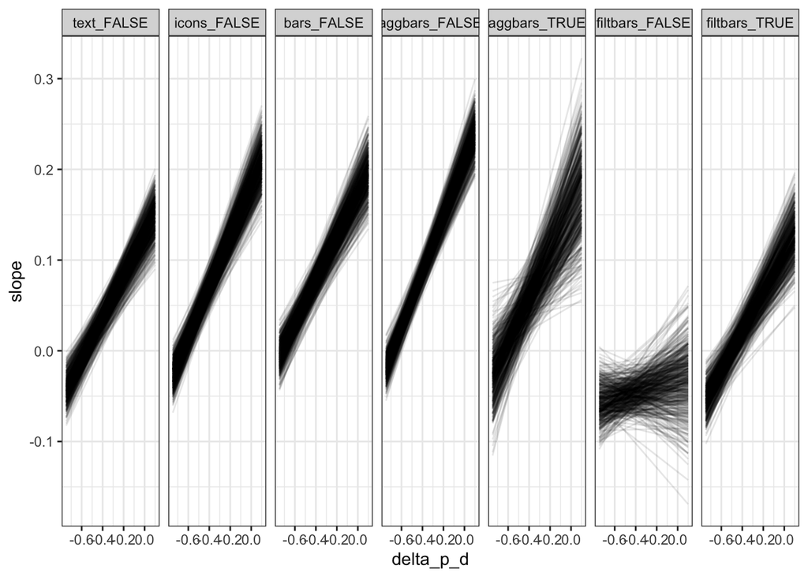

```r
slopes_delta_p_d_df %>%
  group_by(delta_p_d, vis, vis_order, .draw) %>%  # group by predictors to keep
  summarise(slope = weighted.mean(slope)) %>%     # marginalize
  ggplot(aes(x = delta_p_d, y = slope, group = .draw)) +
    geom_line(alpha = 0.1) +
    theme_bw() +
    facet_grid(. ~ reorder(vis, vis_order))
```

```r
# figure for paper
plt <- slopes_delta_p_d_df %>%
  group_by(delta_p_d, vis, vis_order, .draw) %>%  # group by predictors to keep
  summarise(slope = weighted.mean(slope)) %>%     # marginalize
  ggplot(aes(x = delta_p_d, y = slope, group = .draw)) +
    geom_line(alpha = 0.1) +
    theme_minimal() +
    theme(
      axis.title = element_blank(),
      panel.grid.minor = element_blank(),
      strip.text = element_blank()
    ) +
    facet_grid(. ~ reorder(vis, vis_order))

plt
# ggsave("../../figures/components/e2-delta-p-d.svg", plt, width = 7, height = 1.5)
```

We can see that especially in the conditions where users perform the best overall (i.e., text, icons, bars, aggbars_FALSE, and filtbars_TRUE), users are more sensitive to signal (slopes closer to 1) in the charts when delta p disease is more positive. This suggests that users are more sensitive to evidence against an effect of gene on disease than evidence for one.

Interestingly, this pattern seems to scatter somewhat when users interact with aggbars, with less sensitively at delta p disease near zero. This may help to explain poorer performance when users interact with aggbars. Note that we expected interacting with aggbars would help with this comparison because of the ability to collapse across levels of treatment and more directly query the main effects of gene on disease. Maybe the poorer-than-expected sensitivity with aggbars is due to heterogeneity in how users interact?

Conversely, users become a lot more sensitive to positive delta p disease when they interact with filtbars. In the paper, we remark on why we might see disproportionate sensitivity evidence falsifying a causal relationship rather than verifying one.

Next, let’s look at the *interaction between delta p treatment and visualization condition on LLO slopes*. Similar to the previous charts, lines should be flat with a y-intercept of 1 in an ideal observer.

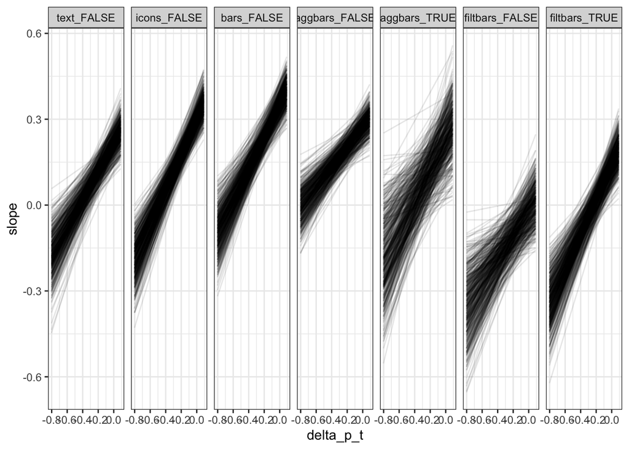

```r
slopes_delta_p_t_df %>%
  group_by(delta_p_t, vis, vis_order, .draw) %>%  # group by predictors to keep
  summarise(slope = weighted.mean(slope)) %>%     # marginalize
  ggplot(aes(x = delta_p_t, y = slope, group = .draw)) +
    geom_line(alpha = 0.1) +
    theme_bw() +
    facet_grid(. ~ reorder(vis, vis_order))
```

```r
# figure for paper
plt <- slopes_delta_p_t_df %>%
  group_by(delta_p_t, vis, vis_order, .draw) %>%  # group by predictors to keep
  summarise(slope = weighted.mean(slope)) %>%     # marginalize
  ggplot(aes(x = delta_p_t, y = slope, group = .draw)) +
    geom_line(alpha = 0.1) +
    theme_minimal() +
    theme(
      axis.title = element_blank(),
      panel.grid.minor = element_blank(),
      strip.text = element_blank()
    ) +
    facet_grid(. ~ reorder(vis, vis_order))

plt
# ggsave("../../figures/components/e2-delta-p-t.svg", plt, width = 7, height = 1.5)
```

Similar to the gene effect on disease, chart users are more sensitive to evidence against a gene effect on treatment than evidence in favor of the effect of gene on treatment. This greater sensitivity to falsifying than confirment evidence seems to be a ubiquitous pattern in our results across E1 and E2, regardless of which arrow in a DAG the chart user is assessing their belief in.

We can see that this pattern is somewhat scattered or more variable with aggbars_TRUE and filtbars_FALSE. It is somewhat surprising that users can see this signal at all with filtbars when they don’t interact. Maybe users pick up on the overall greater rate of disease when the gene stops the treatment from working. Some of this variability may also be due to a lower number of trials where aggbars users interact or filtbars users don’t interact.

Now, let’s look at the *interaction between sample size and visualization condition on LLO slopes*.

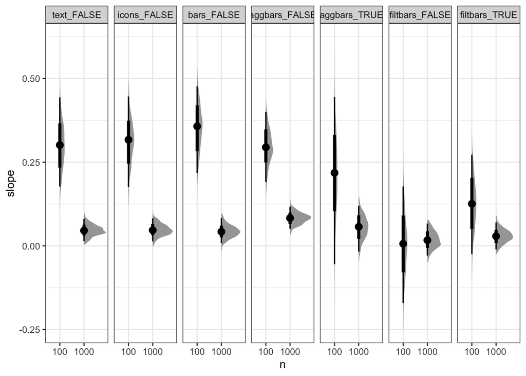

```r
results_df %>%
  group_by(n, vis, vis_order, .draw) %>%          # group by predictors to keep
  summarise(slope = weighted.mean(slope)) %>%     # marginalize
  ggplot(aes(x = n, y = slope)) +
    stat_halfeye() +
    theme_bw() +
    facet_grid(. ~ reorder(vis, vis_order))
```

```r
# figure for paper
plt <- results_df %>%
  group_by(n, vis, vis_order, .draw) %>%      # group by predictors to keep
  summarise(slope = weighted.mean(slope)) %>% # marginalize
  ggplot(aes(x = n, y = slope)) +
    stat_slab() +
    theme_minimal() +
    theme(
      axis.title = element_blank(),
      panel.grid.minor = element_blank(),
      strip.text = element_blank()
    ) +
    facet_grid(. ~ reorder(vis, vis_order))

plt
# ggsave("../../figures/components/e2-n.svg", plt, width = 7, height = 1.5)
```

We see that users are less sensitive to the signal in charts at larger sample size, with the exception of the filtbars_TRUE condition where this pattern is less pronounced, and filtbars_FALSE, where performance is poor across the board. Perhaps users are more sensitive at the smaller sample size because the relatively small amount of data is a cue that strong inferences are not warranted. Although, this pattern may be more of a perceptual bias than a cognitive one. This result is consistent with our results in E1 as well as prior work showing that people underestimate the number of items in a set and underestimate sample size for the purpose of making visual inferences with data.

### User interactions with aggbars and filtbars

Let’s analyze how users interacted with the aggbars and filtbars visualization conditions, respectively.

We’ll start by writing functions to reconstruct the state of each visualization on each trial based on interaction logs.

```r
reconstruct_state_aggbars <- function(interactions) {
  # starting state is conditioning on both gene and treatment
  states <- list("gene_treat_init")

  for(i in 1:length(interactions)) {
    if (interactions[i] == "collapseRow" & str_detect(states[length(states)], "^gene_treat")) {
      states <- append(states, list("treat"))
    } else if (interactions[i] == "collapseRow" & states[length(states)] == "gene") {
      states <- append(states, list("none"))
    } else if (interactions[i] == "expandRow" & states[length(states)] == "treat") {
      states <- append(states, list("gene_treat"))
    } else if (interactions[i] == "expandRow" & states[length(states)] == "none") {
      states <- append(states, list("gene"))
    } else if (interactions[i] == "collapseCol" & str_detect(states[length(states)], "^gene_treat")) {
      states <- append(states, list("gene"))
    } else if (interactions[i] == "collapseCol" & states[length(states)] == "treat") {
      states <- append(states, list("none"))
    } else if (interactions[i] == "expandCol" & states[length(states)] == "gene") {
      states <- append(states, list("gene_treat"))
    } else if (interactions[i] == "expandCol" & states[length(states)] == "none") {
      states <- append(states, list("treat"))
    }
  }

  return(unlist(states))
}
```

```r
reconstruct_state_filtbars <- function(interactions) {
  # starting state is conditioning on nothing
  states <- list("none_init")
  curr <- "" # state is a chain of filters

  for(i in 1:length(interactions)) {
    if (interactions[i] == "clearFilters") {
      curr <- ""
      states <- append(states, list("none"))
    } else if (str_detect(interactions[i], "^filter") & str_detect(states[length(states)], "^none")) {
      # first filter
      curr <- sub("^filter", "", interactions[i])
      states <- append(states, list(curr))
    } else if (str_detect(interactions[i], "^filter") & !str_detect(curr, paste(".*", sub("^filter", "", interactions[i]), ".*", sep = ""))) {
      # only add interactions not already in the chain (don't log duplicate filters which do not change the state)
      # put chain of filters including the current one into consistent order (so string matching can identify unique states)
      curr <- pmap_chr(list(curr, sub("^filter", "", interactions[i])), ~paste(sort(c(...)), collapse = "_"))
      states <- append(states, list(curr))
    }
  }

  return(unlist(states))
}
```

Now, we’ll reconstruct the states visited on each trial for each visualization separately.

```r
aggbars_df <- model_df %>%
  filter(condition == "aggbars") %>%
  rowwise() %>%
  mutate(
    interactions = str_split(interactions, "_"),
    state = list(reconstruct_state_aggbars(interactions))
  )
```

```r
filtbars_df <- model_df %>%
  filter(condition == "filtbars") %>%
  rowwise() %>%
  mutate(
    interactions = str_split(interactions, "_"),
    state = list(reconstruct_state_filtbars(interactions))
  )
```

Let’s view histograms of the states visited by users of aggbars and filtbars.

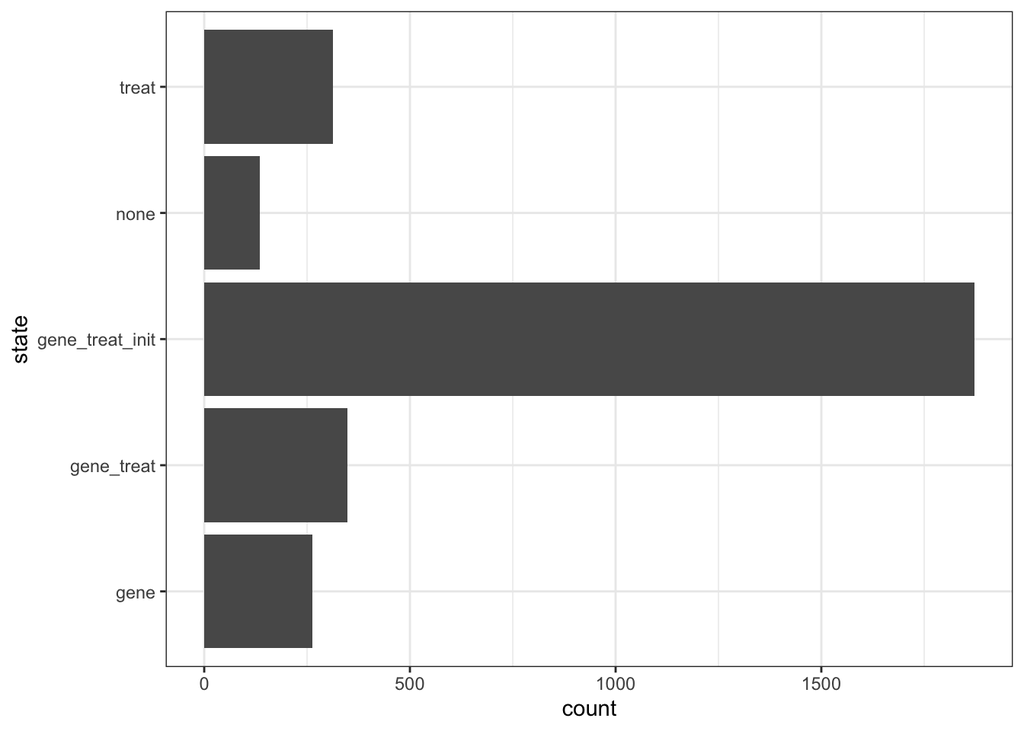

```r
aggbars_df %>%
  group_by(trial, workerId) %>%
  unnest(cols = c("state")) %>%
  ggplot(aes(y = state)) +
  geom_bar() +
  theme_bw()
```

We can see that aggbars users create views conditioning on treatment slightly more than they create views conditioning on gene. Perhaps users collapse across levels of gene (i.e., conditioning on treatment only) as a way of investigating whether gene seems ignorable.

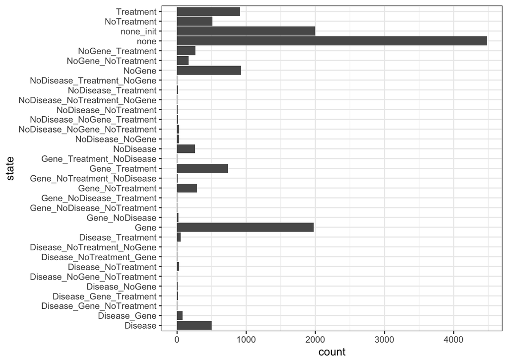

```r
filtbars_df %>%
  group_by(trial, workerId) %>%
  unnest(cols = c("state")) %>%
  ggplot(aes(y = state)) +
  geom_bar() +
  theme_bw()
```

For both aggbars and filtbars, let’s see what proportion of users create views that should be most helpful for the task.

For aggbars this means intentionally creating views that condition on gene, which we see in about 13% of trials.

```r
aggbars_df <- aggbars_df %>%
  mutate(
    condition_on_gene = any(str_detect(unlist(state), "^gene*") & !str_detect(unlist(state), "^gene_treat_init$"))
  )

sum(aggbars_df$condition_on_gene) / length(aggbars_df$condition_on_gene)
```

```
## [1] 0.1324786
```

For aggbars, it seems like more users condition on treatment slightly more than gene. Maybe they are looking at whether grouping by or collapsing across gene makes a difference in the proportion of people with disease. Although this is kind of a roundabout way of checking for signal of a marginal effect, it probably does give an intuitive sense of whether gene seems to impact other factors. What proportion of trials to aggbars users intentionally create views that condition on treat (after seeing an initial disaggregated view conditioning on both gene and treat)? Looks like about 12% of trials.

```r
aggbars_df <- aggbars_df %>%
  mutate(
    condition_on_treat = any(str_detect(unlist(state), "^treat$"))
  )

sum(aggbars_df$condition_on_treat) / length(aggbars_df$condition_on_treat)
```

```
## [1] 0.1185897
```

For filtbars creating the most task-relevant views means intentionally creating views that condition on both gene and no gene, which we see in about 27% of trials.

```r
filtbars_df <- filtbars_df %>%
  mutate(
    condition_on_gene_nogene = any(str_detect(unlist(state), "^Gene*")) & any(str_detect(unlist(state), "^NoGene*"))
  )

sum(filtbars_df$condition_on_gene_nogene) / length(filtbars_df$condition_on_gene_nogene)
```

```
## [1] 0.2747748
```

For filtbars, it seems like more users condition on gene than no gene, and more condition on Gene_Treatment than NoGene_Treatment. Maybe they are comparing the subset of data where people have the gene to the overall data. Although this is not as rigorous as conditioning on both gene and no gene in turn, it shows task relevant signal. What proportion of trials to filtbars users intentionally create views that condition on gene? Looks like about 50% of trials.

```r
filtbars_df <- filtbars_df %>%
  mutate(
    condition_on_gene = any(str_detect(unlist(state), "^Gene*"))
  )

sum(filtbars_df$condition_on_gene) / length(filtbars_df$condition_on_gene)
```

```
## [1] 0.4974975
```

Users of filtbars create the most task-relevant views of the data more often than aggbars users. They also interact with the visualization much more frequently overall. Perhaps the greater heterogeneity and lower frequency of interactive queries with aggbars helps to explain why interacting with aggbars seems to make sensitivity worse on average, whereas interacting with filtbars does seem to improve sensitivity.

### Confidence

We also collected overall confidence ratings from participants at the end of the experiment. Let’s look at conidence as a function of the average absolute error across trials for each participant.

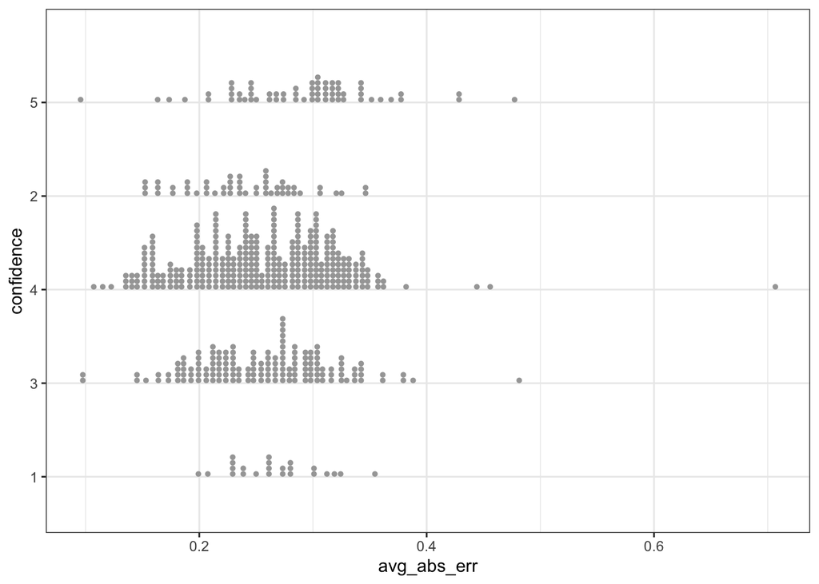

```r
model_df %>%
  group_by(workerId) %>%
  summarise(
    avg_abs_err = mean(abs_err),
    confidence = unique(as.factor(confidence)),
    vis = unique(vis)
  ) %>%
  ggplot(aes(x = avg_abs_err, y = confidence)) +
  stat_dotsh() +
  theme_bw()
```

We can see that absolute error is consistently high at all levels of confidence. This suggests that workers did not know how to guage their performance on the task.